# Project: Identify Customer Segments

### Step 1.2: Select and Re-Encode Features

Checking for missing data isn't the only way in which you can prepare a dataset for analysis. Since the unsupervised learning techniques to be used will only work on data that is encoded numerically, you need to make a few encoding changes or additional assumptions to be able to make progress. In addition, while almost all of the values in the dataset are encoded using numbers, not all of them represent numeric values. Check the third column of the feature summary (`feat_info`) for a summary of types of measurement.

- For numeric and interval data, these features can be kept without changes.
- Most of the variables in the dataset are ordinal in nature. While ordinal values may technically be non-linear in spacing, make the simplifying assumption that the ordinal variables can be treated as being interval in nature (that is, kept without any changes).
- Special handling may be necessary for the remaining two variable types: categorical, and 'mixed'.

In the first two parts of this sub-step, you will perform an investigation of the categorical and mixed-type features and make a decision on each of them, whether you will keep, drop, or re-encode each. Then, in the last part, you will create a new data frame with only the selected and engineered columns.

Data wrangling is often the trickiest part of the data analysis process, and there's a lot of it to be done here. But stick with it: once you're done with this step, you'll be ready to get to the machine learning parts of the project!

```python
# total features before filtering the datasets
len(feat_info)
```

```
85
```

```python
# Create new feature table with just features of the chosen dataset
feat_info_filtered = feat_info[feat_info['attribute'].isin(azdiasNaN20)]
```

```python
# total features before filtering the datasets
len(feat_info_filtered)
```

```
79
```

```python
# How many features are there of each data type?
# features = feat_info[azdiasNaN20.columns]
len(feat_info_filtered['type'].unique())
```

```
4
```

#### Step 1.2.1: Re-Encode Categorical Features

For categorical data, you would ordinarily need to encode the levels as dummy variables. Depending on the number of categories, perform one of the following:

- For binary (two-level) categoricals that take numeric values, you can keep them without needing to do anything.
- There is one binary variable that takes on non-numeric values. For this one, you need to re-encode the values as numbers or create a dummy variable.
- For multi-level categoricals (three or more values), you can choose to encode the values using multiple dummy variables (e.g. via [OneHotEncoder](http://scikit-learn.org/stable/modules/generated/sklearn.preprocessing.OneHotEncoder.html)), or (to keep things straightforward) just drop them from the analysis. As always, document your choices in the Discussion section.

```python
# Assess categorical variables: which are binary, which are multi-level, and
# which one needs to be re-encoded?
feat_info_filtered.groupby("type").count()
```

| type | attribute | information_level | missing_or_unknown |
| --- | --- | --- | --- |
| categorical | 18 | 18 | 18 |
| mixed | 6 | 6 | 6 |
| numeric | 6 | 6 | 6 |
| ordinal | 49 | 49 | 49 |

```python
# Re-encode categorical variable(s) to be kept in the analysis.
categoricalFeatures = feat_info_filtered[feat_info_filtered["type"] == "categorical"]['attribute'].tolist()
```

```python
azdiasNaN20[categoricalFeatures].nunique().sort_values()
```

```
ANREDE_KZ            2
OST_WEST_KZ          2
VERS_TYP             2
SOHO_KZ              2
GREEN_AVANTGARDE     2
NATIONALITAET_KZ     3
SHOPPER_TYP          4
LP_STATUS_GROB       5
LP_FAMILIE_GROB      5
FINANZTYP            6
ZABEOTYP             6
CJT_GESAMTTYP        6
GEBAEUDETYP          7
CAMEO_DEUG_2015      9
LP_STATUS_FEIN      10
LP_FAMILIE_FEIN     11
GFK_URLAUBERTYP     12
CAMEO_DEU_2015      44
dtype: int64
```

These we can let as binary:  
ANREDE_KZ 2  
OST_WEST_KZ 2  
VERS_TYP 2  
SOHO_KZ 2  
GREEN_AVANTGARDE 2

These we have to consider multi-level categories NATIONALITAET_KZ 3  
SHOPPER_TYP 4  
LP_STATUS_GROB 5  
LP_FAMILIE_GROB 5  
FINANZTYP 6  
ZABEOTYP 6  
CJT_GESAMTTYP 6  
GEBAEUDETYP 7  
CAMEO_DEUG_2015 9  
LP_STATUS_FEIN 10  
LP_FAMILIE_FEIN 11  
GFK_URLAUBERTYP 12  
CAMEO_DEU_2015 44

```python
categoricalFeaturesBinary = azdiasNaN20[categoricalFeatures].nunique() < 3
categoricalFeaturesBinary = categoricalFeaturesBinary[categoricalFeaturesBinary].index.values

categoricalFeaturesMulti  = azdiasNaN20[categoricalFeatures].nunique() > 2
categoricalFeaturesMulti = categoricalFeaturesMulti[categoricalFeaturesMulti].index.values
```

```python
categoricalFeaturesMulti
```

```
array(['CJT_GESAMTTYP', 'FINANZTYP', 'GFK_URLAUBERTYP', 'LP_FAMILIE_FEIN',
       'LP_FAMILIE_GROB', 'LP_STATUS_FEIN', 'LP_STATUS_GROB',
       'NATIONALITAET_KZ', 'SHOPPER_TYP', 'ZABEOTYP', 'GEBAEUDETYP',
       'CAMEO_DEUG_2015', 'CAMEO_DEU_2015'], dtype=object)
```

```python
# let's take a look in the binary features so recognize which one is literal
azdiasNaN20[categoricalFeaturesBinary].head(10)
```

|  | ANREDE_KZ | GREEN_AVANTGARDE | SOHO_KZ | VERS_TYP | OST_WEST_KZ |
| --- | --- | --- | --- | --- | --- |
| 1 | 2 | 0 | 1.0 | 2.0 | W |
| 2 | 2 | 1 | 0.0 | 1.0 | W |
| 3 | 2 | 0 | 0.0 | 1.0 | W |
| 4 | 1 | 0 | 0.0 | 2.0 | W |
| 5 | 2 | 0 | 0.0 | 2.0 | W |
| 6 | 2 | 0 | 0.0 | 1.0 | W |
| 7 | 1 | 0 | 0.0 | 1.0 | W |
| 8 | 1 | 1 | 0.0 | 2.0 | W |
| 9 | 2 | 1 | 0.0 | 2.0 | W |
| 10 | 2 | 0 | 0.0 | 2.0 | W |

```python
azdiasNaN20.drop(categoricalFeaturesMulti, axis=1, inplace=True)
```

```python
azdiasNaN20.head(10)
```

|  | ALTERSKATEGORIE_GROB | ANREDE_KZ | FINANZ_MINIMALIST | FINANZ_SPARER | FINANZ_VORSORGER | FINANZ_ANLEGER | FINANZ_UNAUFFAELLIGER | FINANZ_HAUSBAUER | GREEN_AVANTGARDE | HEALTH_TYP | ... | PLZ8_ANTG1 | PLZ8_ANTG2 | PLZ8_ANTG3 | PLZ8_ANTG4 | PLZ8_BAUMAX | PLZ8_HHZ | PLZ8_GBZ | ARBEIT | ORTSGR_KLS9 | RELAT_AB |
| --- | --- | --- | --- | --- | --- | --- | --- | --- | --- | --- | --- | --- | --- | --- | --- | --- | --- | --- | --- | --- | --- |
| 1 | 1.0 | 2 | 1 | 5 | 2 | 5 | 4 | 5 | 0 | 3.0 | ... | 2.0 | 3.0 | 2.0 | 1.0 | 1.0 | 5.0 | 4.0 | 3.0 | 5.0 | 4.0 |
| 2 | 3.0 | 2 | 1 | 4 | 1 | 2 | 3 | 5 | 1 | 3.0 | ... | 3.0 | 3.0 | 1.0 | 0.0 | 1.0 | 4.0 | 4.0 | 3.0 | 5.0 | 2.0 |
| 3 | 4.0 | 2 | 4 | 2 | 5 | 2 | 1 | 2 | 0 | 2.0 | ... | 2.0 | 2.0 | 2.0 | 0.0 | 1.0 | 3.0 | 4.0 | 2.0 | 3.0 | 3.0 |
| 4 | 3.0 | 1 | 4 | 3 | 4 | 1 | 3 | 2 | 0 | 3.0 | ... | 2.0 | 4.0 | 2.0 | 1.0 | 2.0 | 3.0 | 3.0 | 4.0 | 6.0 | 5.0 |
| 5 | 1.0 | 2 | 3 | 1 | 5 | 2 | 2 | 5 | 0 | 3.0 | ... | 2.0 | 3.0 | 1.0 | 1.0 | 1.0 | 5.0 | 5.0 | 2.0 | 3.0 | 3.0 |
| 6 | 2.0 | 2 | 1 | 5 | 1 | 5 | 4 | 3 | 0 | 2.0 | ... | 3.0 | 3.0 | 1.0 | 0.0 | 1.0 | 5.0 | 5.0 | 4.0 | 6.0 | 3.0 |
| 7 | 1.0 | 1 | 3 | 3 | 4 | 1 | 3 | 2 | 0 | 1.0 | ... | 3.0 | 3.0 | 1.0 | 0.0 | 1.0 | 4.0 | 4.0 | 2.0 | 5.0 | 2.0 |
| 8 | 3.0 | 1 | 4 | 4 | 2 | 4 | 2 | 2 | 1 | 3.0 | ... | 2.0 | 3.0 | 2.0 | 1.0 | 1.0 | 3.0 | 3.0 | 2.0 | 4.0 | 3.0 |
| 9 | 3.0 | 2 | 2 | 4 | 2 | 3 | 5 | 4 | 1 | 2.0 | ... | 2.0 | 3.0 | 2.0 | 1.0 | 1.0 | 3.0 | 3.0 | 2.0 | 3.0 | 1.0 |
| 10 | 3.0 | 2 | 2 | 2 | 5 | 3 | 1 | 5 | 0 | 2.0 | ... | 2.0 | 4.0 | 2.0 | 0.0 | 2.0 | 3.0 | 3.0 | 4.0 | 6.0 | 5.0 |

10 rows × 66 columns

```python
# Let's see what are the values for OST_WEST_KZ
display(azdiasNaN20["OST_WEST_KZ"].unique())

# Encode OST_WEST_KZ
azdiasNaN20["OST_WEST_KZ"] = azdiasNaN20["OST_WEST_KZ"].map({"W": 0, "O": 1})
```

```
array(['W', 'O'], dtype=object)
```

#### Discussion 1.2.1: Re-Encode Categorical Features

I dropped the multi-level categories for sake of simplicity and encoded the binary column OST_WEST_KZ

#### Step 1.2.2: Engineer Mixed-Type Features

There are a handful of features that are marked as "mixed" in the feature summary that require special treatment in order to be included in the analysis. There are two in particular that deserve attention; the handling of the rest are up to your own choices:

- "PRAEGENDE_JUGENDJAHRE" combines information on three dimensions: generation by decade, movement (mainstream vs. avantgarde), and nation (east vs. west). While there aren't enough levels to disentangle east from west, you should create two new variables to capture the other two dimensions: an interval-type variable for decade, and a binary variable for movement.
- "CAMEO_INTL_2015" combines information on two axes: wealth and life stage. Break up the two-digit codes by their 'tens'-place and 'ones'-place digits into two new ordinal variables (which, for the purposes of this project, is equivalent to just treating them as their raw numeric values).
- If you decide to keep or engineer new features around the other mixed-type features, make sure you note your steps in the Discussion section.

Be sure to check `Data_Dictionary.md` for the details needed to finish these tasks.

```python
# Let's see the mixed
mixedFeatures = feat_info_filtered[feat_info_filtered["type"]=="mixed"].attribute.tolist()
azdiasNaN20[mixedFeatures].head()
```

|  | LP_LEBENSPHASE_FEIN | LP_LEBENSPHASE_GROB | PRAEGENDE_JUGENDJAHRE | WOHNLAGE | CAMEO_INTL_2015 | PLZ8_BAUMAX |
| --- | --- | --- | --- | --- | --- | --- |
| 1 | 21.0 | 6.0 | 14.0 | 4.0 | 51 | 1.0 |
| 2 | 3.0 | 1.0 | 15.0 | 2.0 | 24 | 1.0 |
| 3 | NaN | NaN | 8.0 | 7.0 | 12 | 1.0 |
| 4 | 32.0 | 10.0 | 8.0 | 3.0 | 43 | 2.0 |
| 5 | 8.0 | 2.0 | 3.0 | 7.0 | 54 | 1.0 |

```python
# Investigate "PRAEGENDE_JUGENDJAHRE" and engineer two new variables.
azdiasNaN20['PRAEGENDE_JUGENDJAHRE'].unique()
```

```
array([ 14.,  15.,   8.,   3.,  10.,  11.,   5.,   9.,   6.,   4.,  nan,
         2.,   1.,  12.,  13.,   7.])
```

```python
PRAEGENDE_JUGENDJAHRE = """-1:
  0:
  1: 40s  war years (Mainstream, E+W)
  2: 40s  reconstruction years (Avantgarde, E+W)
  3: 50s  economic miracle (Mainstream, E+W)
  4: 50s  milk bar / Individualisation (Avantgarde, E+W)
  5: 60s  economic miracle (Mainstream, E+W)
  6: 60s  generation 68 / student protestors (Avantgarde, W)
  7: 60s  opponents to the building of the Wall (Avantgarde, E)
  8: 70s  family orientation (Mainstream, E+W)
  9: 70s  peace movement (Avantgarde, E+W)
 10: 80s  Generation Golf (Mainstream, W)
 11: 80s  ecological awareness (Avantgarde, W)
 12: 80s  FDJ / communist party youth organisation (Mainstream, E)
 13: 80s  Swords into ploughshares (Avantgarde, E)
 14: 90s  digital media kids (Mainstream, E+W)
 15: 90s  ecological awareness (Avantgarde, E+W)"""
```

```python
PRAEGENDE_JUGENDJAHRE_MAP = {}
for i in PRAEGENDE_JUGENDJAHRE.split('\n'):
    idx = i.strip().split(":")[0]
    secondStep = (i.strip().split(":")[1]).strip()
    decade = 0 if (idx == '0' or idx == '-1') else secondStep.replace("0s", "0_").split("_")[0]
    movement = secondStep.split("(")[-1].split(",")[0]
    nation   = secondStep.split("(")[-1].split(",")[-1].strip().replace(")","").split("+")
    PRAEGENDE_JUGENDJAHRE_MAP[idx] = {"decade":decade, "movement":movement, "nation":nation}
print(PRAEGENDE_JUGENDJAHRE_MAP)
```

```
{'-1': {'decade': 0, 'movement': '', 'nation': ['']}, '0': {'decade': 0, 'movement': '', 'nation': ['']}, '1': {'decade': '40', 'movement': 'Mainstream', 'nation': ['E', 'W']}, '2': {'decade': '40', 'movement': 'Avantgarde', 'nation': ['E', 'W']}, '3': {'decade': '50', 'movement': 'Mainstream', 'nat…
```

```python
azdiasNaN20['PRAEGENDE_JUGENDJAHRE'].fillna('-1', inplace=True)
azdiasNaN20['DECADE']   = azdiasNaN20['PRAEGENDE_JUGENDJAHRE'].apply(lambda x: PRAEGENDE_JUGENDJAHRE_MAP[str(int(x))]['decade'])
azdiasNaN20['MOVEMENT'] = azdiasNaN20['PRAEGENDE_JUGENDJAHRE'].apply(lambda x: PRAEGENDE_JUGENDJAHRE_MAP[str(int(x))]['movement'])
# azdiasNaN20['nation']   = azdiasNaN20['PRAEGENDE_JUGENDJAHRE'].apply(lambda x: PRAEGENDE_JUGENDJAHRE_MAP[str(int(x))]['nation'])

# Encode MOVEMENT
azdiasNaN20["MOVEMENT"] = azdiasNaN20["MOVEMENT"].map({"Mainstream": 0, "Avantgarde": 1})
azdiasNaN20.head(20)
```

|  | ALTERSKATEGORIE_GROB | ANREDE_KZ | FINANZ_MINIMALIST | FINANZ_SPARER | FINANZ_VORSORGER | FINANZ_ANLEGER | FINANZ_UNAUFFAELLIGER | FINANZ_HAUSBAUER | GREEN_AVANTGARDE | HEALTH_TYP | ... | PLZ8_ANTG3 | PLZ8_ANTG4 | PLZ8_BAUMAX | PLZ8_HHZ | PLZ8_GBZ | ARBEIT | ORTSGR_KLS9 | RELAT_AB | DECADE | MOVEMENT |
| --- | --- | --- | --- | --- | --- | --- | --- | --- | --- | --- | --- | --- | --- | --- | --- | --- | --- | --- | --- | --- | --- |
| 1 | 1.0 | 2 | 1 | 5 | 2 | 5 | 4 | 5 | 0 | 3.0 | ... | 2.0 | 1.0 | 1.0 | 5.0 | 4.0 | 3.0 | 5.0 | 4.0 | 90 | 0.0 |
| 2 | 3.0 | 2 | 1 | 4 | 1 | 2 | 3 | 5 | 1 | 3.0 | ... | 1.0 | 0.0 | 1.0 | 4.0 | 4.0 | 3.0 | 5.0 | 2.0 | 90 | 1.0 |
| 3 | 4.0 | 2 | 4 | 2 | 5 | 2 | 1 | 2 | 0 | 2.0 | ... | 2.0 | 0.0 | 1.0 | 3.0 | 4.0 | 2.0 | 3.0 | 3.0 | 70 | 0.0 |
| 4 | 3.0 | 1 | 4 | 3 | 4 | 1 | 3 | 2 | 0 | 3.0 | ... | 2.0 | 1.0 | 2.0 | 3.0 | 3.0 | 4.0 | 6.0 | 5.0 | 70 | 0.0 |
| 5 | 1.0 | 2 | 3 | 1 | 5 | 2 | 2 | 5 | 0 | 3.0 | ... | 1.0 | 1.0 | 1.0 | 5.0 | 5.0 | 2.0 | 3.0 | 3.0 | 50 | 0.0 |
| 6 | 2.0 | 2 | 1 | 5 | 1 | 5 | 4 | 3 | 0 | 2.0 | ... | 1.0 | 0.0 | 1.0 | 5.0 | 5.0 | 4.0 | 6.0 | 3.0 | 80 | 0.0 |
| 7 | 1.0 | 1 | 3 | 3 | 4 | 1 | 3 | 2 | 0 | 1.0 | ... | 1.0 | 0.0 | 1.0 | 4.0 | 4.0 | 2.0 | 5.0 | 2.0 | 70 | 0.0 |
| 8 | 3.0 | 1 | 4 | 4 | 2 | 4 | 2 | 2 | 1 | 3.0 | ... | 2.0 | 1.0 | 1.0 | 3.0 | 3.0 | 2.0 | 4.0 | 3.0 | 80 | 1.0 |
| 9 | 3.0 | 2 | 2 | 4 | 2 | 3 | 5 | 4 | 1 | 2.0 | ... | 2.0 | 1.0 | 1.0 | 3.0 | 3.0 | 2.0 | 3.0 | 1.0 | 90 | 1.0 |
| 10 | 3.0 | 2 | 2 | 2 | 5 | 3 | 1 | 5 | 0 | 2.0 | ... | 2.0 | 0.0 | 2.0 | 3.0 | 3.0 | 4.0 | 6.0 | 5.0 | 50 | 0.0 |
| 12 | 3.0 | 1 | 5 | 3 | 4 | 2 | 4 | 1 | 0 | 1.0 | ... | 1.0 | 0.0 | 1.0 | 5.0 | 5.0 | 3.0 | 6.0 | 4.0 | 70 | 0.0 |
| 13 | 1.0 | 2 | 1 | 4 | 3 | 5 | 5 | 2 | 1 | 3.0 | ... | 1.0 | 1.0 | 1.0 | 3.0 | 3.0 | 3.0 | 6.0 | 4.0 | 90 | 1.0 |
| 15 | 4.0 | 2 | 4 | 1 | 5 | 1 | 1 | 4 | 0 | 2.0 | ... | NaN | NaN | NaN | NaN | NaN | 4.0 | 8.0 | 5.0 | 60 | 0.0 |
| 16 | 1.0 | 2 | 4 | 3 | 1 | 4 | 5 | 1 | 0 | 3.0 | ... | 1.0 | 0.0 | 1.0 | 3.0 | 4.0 | 1.0 | 2.0 | 1.0 | 90 | 0.0 |
| 18 | 2.0 | 2 | 2 | 4 | 1 | 5 | 4 | 1 | 0 | 2.0 | ... | 2.0 | 1.0 | 1.0 | 3.0 | 3.0 | 3.0 | 4.0 | 3.0 | 80 | 0.0 |
| 19 | 3.0 | 1 | 5 | 2 | 3 | 1 | 3 | 1 | 1 | 3.0 | ... | 2.0 | 1.0 | 2.0 | 5.0 | 4.0 | 4.0 | 6.0 | 3.0 | 70 | 1.0 |
| 20 | 2.0 | 2 | 4 | 3 | 1 | 4 | 5 | 1 | 1 | 3.0 | ... | NaN | NaN | NaN | NaN | NaN | 3.0 | 4.0 | 1.0 | 80 | 1.0 |
| 21 | 2.0 | 1 | 3 | 4 | 1 | 2 | 5 | 1 | 0 | 2.0 | ... | 3.0 | 2.0 | 4.0 | 4.0 | 3.0 | 5.0 | 7.0 | 5.0 | 80 | 0.0 |
| 22 | 1.0 | 1 | 1 | 5 | 3 | 5 | 5 | 5 | 0 | 2.0 | ... | 2.0 | 1.0 | 2.0 | 4.0 | 3.0 | 4.0 | 5.0 | 5.0 | 90 | 0.0 |
| 23 | 3.0 | 1 | 5 | 3 | 3 | 2 | 2 | 1 | 1 | 3.0 | ... | NaN | NaN | NaN | NaN | NaN | 3.0 | 6.0 | 2.0 | 70 | 1.0 |

20 rows × 68 columns

```python
# Investigate "CAMEO_INTL_2015" and engineer two new variables.
azdiasNaN20['CAMEO_INTL_2015'].unique()
```

```
array(['51', '24', '12', '43', '54', '22', '14', '13', '15', '33', '41',
       '34', '55', nan, '25', '23', '31', '52', '35', '45', '44', '32'], dtype=object)
```

### 4.3. CAMEO_INTL_2015

German CAMEO: Wealth / Life Stage Typology, mapped to international code

- -1: unknown
- 11: Wealthy Households - Pre-Family Couples & Singles
- 12: Wealthy Households - Young Couples With Children
- 13: Wealthy Households - Families With School Age Children
- 14: Wealthy Households - Older Families & Mature Couples
- 15: Wealthy Households - Elders In Retirement
- 21: Prosperous Households - Pre-Family Couples & Singles
- 22: Prosperous Households - Young Couples With Children
- 23: Prosperous Households - Families With School Age Children
- 24: Prosperous Households - Older Families & Mature Couples
- 25: Prosperous Households - Elders In Retirement
- 31: Comfortable Households - Pre-Family Couples & Singles
- 32: Comfortable Households - Young Couples With Children
- 33: Comfortable Households - Families With School Age Children
- 34: Comfortable Households - Older Families & Mature Couples
- 35: Comfortable Households - Elders In Retirement
- 41: Less Affluent Households - Pre-Family Couples & Singles
- 42: Less Affluent Households - Young Couples With Children
- 43: Less Affluent Households - Families With School Age Children
- 44: Less Affluent Households - Older Families & Mature Couples
- 45: Less Affluent Households - Elders In Retirement
- 51: Poorer Households - Pre-Family Couples & Singles
- 52: Poorer Households - Young Couples With Children
- 53: Poorer Households - Families With School Age Children
- 54: Poorer Households - Older Families & Mature Couples
- 55: Poorer Households - Elders In Retirement
- XX: unknown

```python
# Transform double digit in a single digit for wealthy and life stage, also replace "s" by NaN
azdiasNaN20['WEALTHY'] = azdiasNaN20['CAMEO_INTL_2015'].apply(lambda x: str(x)[0])
azdiasNaN20['LIFESTAGE'] = azdiasNaN20['CAMEO_INTL_2015'].apply(lambda x: str(x)[1])
azdiasNaN20['WEALTHY'] = azdiasNaN20['WEALTHY'].replace('a', np.NaN)
azdiasNaN20['LIFESTAGE'] = azdiasNaN20['LIFESTAGE'].replace('a', np.NaN)
```

```python
azdiasNaN20['LIFESTAGE'].unique()
```

```
array(['1', '4', '2', '3', '5', nan], dtype=object)
```

```python
azdiasNaN20.head(10)
```

|  | ALTERSKATEGORIE_GROB | ANREDE_KZ | FINANZ_MINIMALIST | FINANZ_SPARER | FINANZ_VORSORGER | FINANZ_ANLEGER | FINANZ_UNAUFFAELLIGER | FINANZ_HAUSBAUER | GREEN_AVANTGARDE | HEALTH_TYP | ... | PLZ8_BAUMAX | PLZ8_HHZ | PLZ8_GBZ | ARBEIT | ORTSGR_KLS9 | RELAT_AB | DECADE | MOVEMENT | WEALTHY | LIFESTAGE |
| --- | --- | --- | --- | --- | --- | --- | --- | --- | --- | --- | --- | --- | --- | --- | --- | --- | --- | --- | --- | --- | --- |
| 1 | 1.0 | 2 | 1 | 5 | 2 | 5 | 4 | 5 | 0 | 3.0 | ... | 1.0 | 5.0 | 4.0 | 3.0 | 5.0 | 4.0 | 90 | 0.0 | 5 | 1 |
| 2 | 3.0 | 2 | 1 | 4 | 1 | 2 | 3 | 5 | 1 | 3.0 | ... | 1.0 | 4.0 | 4.0 | 3.0 | 5.0 | 2.0 | 90 | 1.0 | 2 | 4 |
| 3 | 4.0 | 2 | 4 | 2 | 5 | 2 | 1 | 2 | 0 | 2.0 | ... | 1.0 | 3.0 | 4.0 | 2.0 | 3.0 | 3.0 | 70 | 0.0 | 1 | 2 |
| 4 | 3.0 | 1 | 4 | 3 | 4 | 1 | 3 | 2 | 0 | 3.0 | ... | 2.0 | 3.0 | 3.0 | 4.0 | 6.0 | 5.0 | 70 | 0.0 | 4 | 3 |
| 5 | 1.0 | 2 | 3 | 1 | 5 | 2 | 2 | 5 | 0 | 3.0 | ... | 1.0 | 5.0 | 5.0 | 2.0 | 3.0 | 3.0 | 50 | 0.0 | 5 | 4 |
| 6 | 2.0 | 2 | 1 | 5 | 1 | 5 | 4 | 3 | 0 | 2.0 | ... | 1.0 | 5.0 | 5.0 | 4.0 | 6.0 | 3.0 | 80 | 0.0 | 2 | 2 |
| 7 | 1.0 | 1 | 3 | 3 | 4 | 1 | 3 | 2 | 0 | 1.0 | ... | 1.0 | 4.0 | 4.0 | 2.0 | 5.0 | 2.0 | 70 | 0.0 | 1 | 4 |
| 8 | 3.0 | 1 | 4 | 4 | 2 | 4 | 2 | 2 | 1 | 3.0 | ... | 1.0 | 3.0 | 3.0 | 2.0 | 4.0 | 3.0 | 80 | 1.0 | 1 | 3 |
| 9 | 3.0 | 2 | 2 | 4 | 2 | 3 | 5 | 4 | 1 | 2.0 | ... | 1.0 | 3.0 | 3.0 | 2.0 | 3.0 | 1.0 | 90 | 1.0 | 1 | 5 |
| 10 | 3.0 | 2 | 2 | 2 | 5 | 3 | 1 | 5 | 0 | 2.0 | ... | 2.0 | 3.0 | 3.0 | 4.0 | 6.0 | 5.0 | 50 | 0.0 | 5 | 1 |

10 rows × 70 columns

#### Step 1.2.3: Complete Feature Selection

In order to finish this step up, you need to make sure that your data frame now only has the columns that you want to keep. To summarize, the dataframe should consist of the following:

- All numeric, interval, and ordinal type columns from the original dataset.
- Binary categorical features (all numerically-encoded).
- Engineered features from other multi-level categorical features and mixed features.

Make sure that for any new columns that you have engineered, that you've excluded the original columns from the final dataset. Otherwise, their values will interfere with the analysis later on the project. For example, you should not keep "PRAEGENDE_JUGENDJAHRE", since its values won't be useful for the algorithm: only the values derived from it in the engineered features you created should be retained. As a reminder, your data should only be from **the subset with few or no missing values**.

```python
# If there are other re-engineering tasks you need to perform, make sure you
# take care of them here. (Dealing with missing data will come in step 2.1.)

# Drop CAMEO_INTL_2015 and PRAEGENDE_JUGENDJAHRE
azdiasNaN20.drop(['CAMEO_INTL_2015', 'PRAEGENDE_JUGENDJAHRE'], axis=1, inplace=True)
```

```python
# Do whatever you need to in order to ensure that the dataframe only contains
# the columns that should be passed to the algorithm functions.
```

### Step 1.3: Create a Cleaning Function

Even though you've finished cleaning up the general population demographics data, it's important to look ahead to the future and realize that you'll need to perform the same cleaning steps on the customer demographics data. In this substep, complete the function below to execute the main feature selection, encoding, and re-engineering steps you performed above. Then, when it comes to looking at the customer data in Step 3, you can just run this function on that DataFrame to get the trimmed dataset in a single step.

```python
def clean_data(df):
    """
    Perform feature trimming, re-encoding, and engineering for demographics
    data

    INPUT: Demographics DataFrame
    OUTPUT: Trimmed and cleaned demographics DataFrame
    """
    # Reset feat_info
    feat_info = pd.read_csv("AZDIAS_Feature_Summary.csv", delimiter=";")

    # Identify missing or unknown data values and convert them to NaNs.
    feat_info['missing_or_unknown'] = feat_info['missing_or_unknown'].apply(lambda x: ast.literal_eval(x.replace("X", "'X'").replace("XX", "'XX'")))
    for idx, el in feat_info.iterrows():
        for i in el['missing_or_unknown']:
            attr = el['attribute']
            df[attr].replace(i, np.NaN, inplace=True)

    # remove nulls
    nonZeroAzDias = df.isnull().sum()
    nonZeroAzDias = nonZeroAzDias[nonZeroAzDias > 0].sort_values()

    df.drop(['ALTER_HH', 'GEBURTSJAHR', 'KBA05_BAUMAX', 'KK_KUNDENTYP', 'AGER_TYP',
       'TITEL_KZ'], axis=1, inplace=True)

    # Get just first part of the dataset
    df = df[df.isnull().sum(axis=1) < 30]

    PRAEGENDE_JUGENDJAHRE = """-1:
      0:
      1: 40s  war years (Mainstream, E+W)
      2: 40s  reconstruction years (Avantgarde, E+W)
      3: 50s  economic miracle (Mainstream, E+W)
      4: 50s  milk bar / Individualisation (Avantgarde, E+W)
      5: 60s  economic miracle (Mainstream, E+W)
      6: 60s  generation 68 / student protestors (Avantgarde, W)
      7: 60s  opponents to the building of the Wall (Avantgarde, E)
      8: 70s  family orientation (Mainstream, E+W)
      9: 70s  peace movement (Avantgarde, E+W)
     10: 80s  Generation Golf (Mainstream, W)
     11: 80s  ecological awareness (Avantgarde, W)
     12: 80s  FDJ / communist party youth organisation (Mainstream, E)
     13: 80s  Swords into ploughshares (Avantgarde, E)
     14: 90s  digital media kids (Mainstream, E+W)
     15: 90s  ecological awareness (Avantgarde, E+W)"""

    # Create dict with decade, movement and nation
    PRAEGENDE_JUGENDJAHRE_MAP = {}
    for i in PRAEGENDE_JUGENDJAHRE.split('\n'):
        idx        = i.strip().split(":")[0]
        secondStep = (i.strip().split(":")[1]).strip()
        decade     = 0 if (idx == '0' or idx == '-1') else secondStep.replace("0s", "0_").split("_")[0]
        movement   = secondStep.split("(")[-1].split(",")[0]
        nation     = secondStep.split("(")[-1].split(",")[-1].strip().replace(")","").split("+")
        PRAEGENDE_JUGENDJAHRE_MAP[idx] = {"decade":decade, "movement":movement, "nation":nation}

    # Transform PRAEGENDE_JUGENDJAHRE and map to PRAEGENDE_JUGENDJAHRE_MAP
    df['PRAEGENDE_JUGENDJAHRE'].fillna('-1', inplace=True)
    df['DECADE']   = df['PRAEGENDE_JUGENDJAHRE'].apply(lambda x: PRAEGENDE_JUGENDJAHRE_MAP[str(int(x))]['decade'])
    df['MOVEMENT'] = df['PRAEGENDE_JUGENDJAHRE'].apply(lambda x: PRAEGENDE_JUGENDJAHRE_MAP[str(int(x))]['movement'])

    # Find multi-category features and drop
    categoricalFeaturesMulti  = df[categoricalFeatures].nunique() > 2
    categoricalFeaturesMulti = categoricalFeaturesMulti[categoricalFeaturesMulti].index.values
    df.drop(categoricalFeaturesMulti, axis=1, inplace=True)

    # Encode binary variables
    df["MOVEMENT"]    = df["MOVEMENT"].map({"Mainstream": 0, "Avantgarde": 1})
    df["OST_WEST_KZ"] = df["OST_WEST_KZ"].map({"W": 0, "O": 1})

    # Transform double digit in a single digit for wealthy and life stage, also replace "s" by NaN
    df['WEALTHY']   = df['CAMEO_INTL_2015'].apply(lambda x: str(x)[0])
    df['LIFESTAGE'] = df['CAMEO_INTL_2015'].apply(lambda x: str(x)[1])
    df['WEALTHY']   = df['WEALTHY'].replace('a', np.NaN)
    df['LIFESTAGE'] = df['LIFESTAGE'].replace('a', np.NaN)

    # Drop CAMEO_INTL_2015 and PRAEGENDE_JUGENDJAHRE
    df.drop(['CAMEO_INTL_2015', 'PRAEGENDE_JUGENDJAHRE'], axis=1, inplace=True)

    # Drop nan's
    df.dropna(axis=0, inplace=True)

    return df
```

## Step 2: Feature Transformation

### Step 2.1: Apply Feature Scaling

Before we apply dimensionality reduction techniques to the data, we need to perform feature scaling so that the principal component vectors are not influenced by the natural differences in scale for features. Starting from this part of the project, you'll want to keep an eye on the [API reference page for sklearn](http://scikit-learn.org/stable/modules/classes.html) to help you navigate to all of the classes and functions that you'll need. In this substep, you'll need to check the following:

- sklearn requires that data not have missing values in order for its estimators to work properly. So, before applying the scaler to your data, make sure that you've cleaned the DataFrame of the remaining missing values. This can be as simple as just removing all data points with missing data, or applying an [Imputer](http://scikit-learn.org/stable/modules/generated/sklearn.preprocessing.Imputer.html) to replace all missing values. You might also try a more complicated procedure where you temporarily remove missing values in order to compute the scaling parameters before re-introducing those missing values and applying imputation. Think about how much missing data you have and what possible effects each approach might have on your analysis, and justify your decision in the discussion section below.
- For the actual scaling function, a [StandardScaler](http://scikit-learn.org/stable/modules/generated/sklearn.preprocessing.StandardScaler.html) instance is suggested, scaling each feature to mean 0 and standard deviation 1.
- For these classes, you can make use of the `.fit_transform()` method to both fit a procedure to the data as well as apply the transformation to the data at the same time. Don't forget to keep the fit sklearn objects handy, since you'll be applying them to the customer demographics data towards the end of the project.

```python
# If you've not yet cleaned the dataset of all NaN values, then investigate and
# do that now.
azdiasNaN20.dropna(axis=0, inplace=True)
```

```python
# Apply feature scaling to the general population demographics data.
scaler = StandardScaler().fit(azdiasNaN20)
azdiasNaN20Scaled = scaler.transform(azdiasNaN20)
```

```python
azdiasNaN20Scaled[0]
```

```
array([ -1.74629110e+00,   9.77824759e-01,  -1.51222382e+00,
         1.58105790e+00,  -1.04504228e+00,   1.53905822e+00,
         1.04707261e+00,   1.34048174e+00,  -5.53670199e-01,
         1.04464650e+00,   3.85252400e-01,   2.79536968e-01,
        -1.66569002e+00,   3.88387076e-01,  -4.10415657e-02,
         5.30943963e-02,  -4.21290942e-01,  -1.70458368e+00,
        -1.09039835e+00,  -1.40764195e+00,  -5.93940668e-01,
         1.26568331e+00,  -2.88620580e-01,   1.28508567e+00,
        -1.34391499e-01,   1.49193382e+00,   1.25681057e+00,
         1.08016395e+01,   9.37391601e-01,   1.70630916e-01,
        -6.07322948e-02,   9.78311343e-01,  -6.88380642e-01,
         5.48078468e-01,   1.66227013e-01,  -1.29568203e-01,
        -1.28385266e+00,  -3.44822227e-01,  -5.19208663e-01,
         2.13022594e-03,  -1.06542182e+00,  -1.02411250e+00,
        -6.20111977e-01,   2.68014401e+00,  -1.63165082e+00,
         8.67555217e-01,  -6.01196754e-01,   1.72877130e+00,
        -7.97502311e-01,  -7.44670986e-01,  -1.38449241e+00,
         1.64126920e-01,  -8.04375786e-01,   1.05628847e+00,
        -2.34261169e-01,   1.82484919e-01,   3.74151879e-01,
         3.84669843e-01,  -6.67337465e-01,   1.44159946e+00,
         5.83437841e-01,  -2.01180943e-01,  -1.71845107e-01,
         6.56461513e-01,   1.16445424e+00,  -5.53670199e-01,
         1.14788172e+00,  -1.25110753e+00])
```

### Discussion 2.1: Apply Feature Scaling

As suggested, I decided to apply StandardScaler scaling each feature to mean 0 and standard deviation 1

### Step 2.2: Perform Dimensionality Reduction

On your scaled data, you are now ready to apply dimensionality reduction techniques.

- Use sklearn's [PCA](http://scikit-learn.org/stable/modules/generated/sklearn.decomposition.PCA.html) class to apply principal component analysis on the data, thus finding the vectors of maximal variance in the data. To start, you should not set any parameters (so all components are computed) or set a number of components that is at least half the number of features (so there's enough features to see the general trend in variability).
- Check out the ratio of variance explained by each principal component as well as the cumulative variance explained. Try plotting the cumulative or sequential values using matplotlib's [`plot()`](https://matplotlib.org/api/_as_gen/matplotlib.pyplot.plot.html) function. Based on what you find, select a value for the number of transformed features you'll retain for the clustering part of the project.
- Once you've made a choice for the number of components to keep, make sure you re-fit a PCA instance to perform the decided-on transformation.

```python
# Apply PCA to the data.
pca = PCA(n_components=int(azdiasNaN20Scaled.shape[1]//2))
pcaResult = pca.fit_transform(azdiasNaN20Scaled)
```

```python
# Investigate the variance accounted for by each principal component.
nComponents = len(pca.explained_variance_ratio_)
idxes = np.arange(nComponents)
values = pca.explained_variance_ratio_
```

```python
nComponents
```

```
34
```

```python
idxes
```

```
array([ 0,  1,  2,  3,  4,  5,  6,  7,  8,  9, 10, 11, 12, 13, 14, 15, 16,
       17, 18, 19, 20, 21, 22, 23, 24, 25, 26, 27, 28, 29, 30, 31, 32, 33])
```

```python
values
```

```
array([ 0.17778567,  0.13094436,  0.09099772,  0.0566528 ,  0.04106976,
        0.03254617,  0.03076256,  0.02591339,  0.0227277 ,  0.02087092,
        0.01960762,  0.01890133,  0.01785625,  0.01583203,  0.01535847,
        0.01470291,  0.01431936,  0.01354751,  0.01272892,  0.01218738,
        0.01187686,  0.0112514 ,  0.01092432,  0.01043901,  0.01017878,
        0.00927071,  0.00829623,  0.00741734,  0.00732935,  0.00719025,
        0.00682516,  0.00663501,  0.00623819,  0.00594455])
```

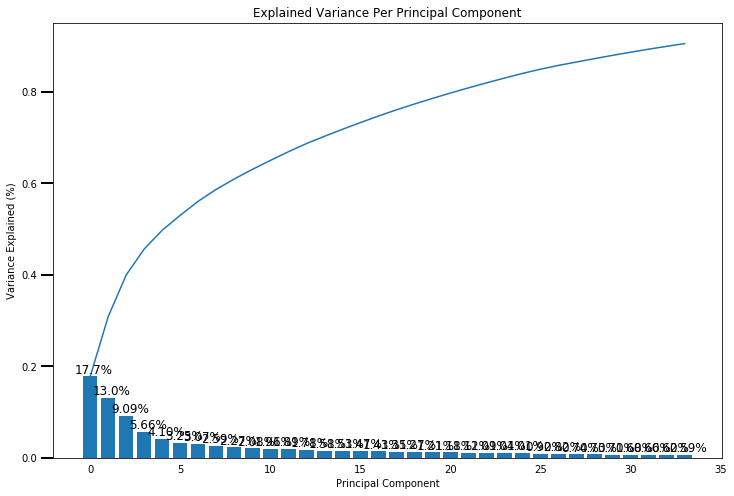

```python
# Code from helper_function.py
plt.figure(figsize=(12, 8))
ax = plt.subplot(111)
cumvals = np.cumsum(values)
ax.bar(idxes, values)
ax.plot(idxes, cumvals)
for i in range(nComponents):
    ax.annotate(r"%s%%" % ((str(values[i]*100)[:4])), (idxes[i]+0.2, values[i]), va="bottom", ha="center", fontsize=12)

ax.xaxis.set_tick_params(width=0)
ax.yaxis.set_tick_params(width=2, length=12)

ax.set_xlabel("Principal Component")
ax.set_ylabel("Variance Explained (%)")
plt.title('Explained Variance Per Principal Component');
```

```python
# Re-apply PCA to the data while selecting for number of components to retain.
pca = PCA(n_components=3)
pcaFit = pca.fit(azdiasNaN20Scaled)
pcaResult = pca.transform(azdiasNaN20Scaled)
```

### Discussion 2.2: Perform Dimensionality Reduction

I decide to keep with 3 components, since they have the most variance in data. Also, it is easier to visualize.

### Step 2.3: Interpret Principal Components

Now that we have our transformed principal components, it's a nice idea to check out the weight of each variable on the first few components to see if they can be interpreted in some fashion.

As a reminder, each principal component is a unit vector that points in the direction of highest variance (after accounting for the variance captured by earlier principal components). The further a weight is from zero, the more the principal component is in the direction of the corresponding feature. If two features have large weights of the same sign (both positive or both negative), then increases in one tend expect to be associated with increases in the other. To contrast, features with different signs can be expected to show a negative correlation: increases in one variable should result in a decrease in the other.

- To investigate the features, you should map each weight to their corresponding feature name, then sort the features according to weight. The most interesting features for each principal component, then, will be those at the beginning and end of the sorted list. Use the data dictionary document to help you understand these most prominent features, their relationships, and what a positive or negative value on the principal component might indicate.
- You should investigate and interpret feature associations from the first three principal components in this substep. To help facilitate this, you should write a function that you can call at any time to print the sorted list of feature weights, for the *i*-th principal component. This might come in handy in the next step of the project, when you interpret the tendencies of the discovered clusters.

```python
# Map weights for the first principal component to corresponding feature names
# and then print the linked values, sorted by weight.
# HINT: Try defining a function here or in a new cell that you can reuse in the
# other cells.

def PCAMap(pcaModel, nComponents, df):
    nComponents -= 1
    mapping = pcaModel.components_[nComponents]
    cols = df.columns.tolist()
    mapDict = {"features": cols,"PCAWeights": mapping}

    df = pd.DataFrame(mapDict).sort_values(by="PCAWeights",axis=0,ascending=False)
    return df
```

```python
azdiasNaN20.columns
```

```
Index(['ALTERSKATEGORIE_GROB', 'ANREDE_KZ', 'FINANZ_MINIMALIST',
       'FINANZ_SPARER', 'FINANZ_VORSORGER', 'FINANZ_ANLEGER',
       'FINANZ_UNAUFFAELLIGER', 'FINANZ_HAUSBAUER', 'GREEN_AVANTGARDE',
       'HEALTH_TYP', 'LP_LEBENSPHASE_FEIN', 'LP_LEBENSPHASE_GROB',
       'RETOURTYP_BK_S', 'SEMIO_SOZ', 'SEMIO_FAM', 'SEMIO_REL', 'SEMIO_MAT',
       'SEMIO_VERT', 'SEMIO_LUST', 'SEMIO_ERL', 'SEMIO_KULT', 'SEMIO_RAT',
       'SEMIO_KRIT', 'SEMIO_DOM', 'SEMIO_KAEM', 'SEMIO_PFLICHT', 'SEMIO_TRADV',
       'SOHO_KZ', 'VERS_TYP', 'ANZ_PERSONEN', 'ANZ_TITEL',
       'HH_EINKOMMEN_SCORE', 'W_KEIT_KIND_HH', 'WOHNDAUER_2008',
       'ANZ_HAUSHALTE_AKTIV', 'ANZ_HH_TITEL', 'KONSUMNAEHE',
       'MIN_GEBAEUDEJAHR', 'OST_WEST_KZ', 'WOHNLAGE', 'KBA05_ANTG1',
       'KBA05_ANTG2', 'KBA05_ANTG3', 'KBA05_ANTG4', 'KBA05_GBZ', 'BALLRAUM',
       'EWDICHTE', 'INNENSTADT', 'GEBAEUDETYP_RASTER', 'KKK', 'MOBI_REGIO',
       'ONLINE_AFFINITAET', 'REGIOTYP', 'KBA13_ANZAHL_PKW', 'PLZ8_ANTG1',
       'PLZ8_ANTG2', 'PLZ8_ANTG3', 'PLZ8_ANTG4', 'PLZ8_BAUMAX', 'PLZ8_HHZ',
       'PLZ8_GBZ', 'ARBEIT', 'ORTSGR_KLS9', 'RELAT_AB', 'DECADE', 'MOVEMENT',
       'WEALTHY', 'LIFESTAGE'],
      dtype='object')
```

```python
pcaList = []
pcaMap1 = PCAMap(pca, 1, azdiasNaN20)
pcaMap1['pcaNb'] = 1
display(pcaMap1[:5])
```

|  | features | PCAWeights | pcaNb |
| --- | --- | --- | --- |
| 56 | PLZ8_ANTG3 | 0.216237 | 1 |
| 57 | PLZ8_ANTG4 | 0.210881 | 1 |
| 58 | PLZ8_BAUMAX | 0.207772 | 1 |
| 66 | WEALTHY | 0.194879 | 1 |
| 31 | HH_EINKOMMEN_SCORE | 0.191270 | 1 |

```python
# Map weights for the second principal component to corresponding feature names
# and then print the linked values, sorted by weight.
pcaMap2 = PCAMap(pca, 2, azdiasNaN20)
pcaMap2['pcaNb'] = 2
display(pcaMap2[:5])
```

|  | features | PCAWeights | pcaNb |
| --- | --- | --- | --- |
| 0 | ALTERSKATEGORIE_GROB | 0.262819 | 2 |
| 19 | SEMIO_ERL | 0.233408 | 2 |
| 4 | FINANZ_VORSORGER | 0.230181 | 2 |
| 18 | SEMIO_LUST | 0.182111 | 2 |
| 12 | RETOURTYP_BK_S | 0.164914 | 2 |

```python
# Map weights for the third principal component to corresponding feature names
# and then print the linked values, sorted by weight.
pcaMap3 = PCAMap(pca, 3, azdiasNaN20)
pcaMap3['pcaNb'] = 3
display(pcaMap3[:5])
pcaMap = pd.concat([pcaMap1[:5], pcaMap2[:5], pcaMap3[:5]]).sort_values(by=['PCAWeights'], ascending=False)
```

|  | features | PCAWeights | pcaNb |
| --- | --- | --- | --- |
| 17 | SEMIO_VERT | 0.349143 | 3 |
| 13 | SEMIO_SOZ | 0.263909 | 3 |
| 14 | SEMIO_FAM | 0.251761 | 3 |
| 20 | SEMIO_KULT | 0.232638 | 3 |
| 2 | FINANZ_MINIMALIST | 0.161426 | 3 |

```python
pcaMap.reset_index(drop=True)
```

|  | features | PCAWeights | pcaNb |
| --- | --- | --- | --- |
| 0 | SEMIO_VERT | 0.349143 | 3 |
| 1 | SEMIO_SOZ | 0.263909 | 3 |
| 2 | ALTERSKATEGORIE_GROB | 0.262819 | 2 |
| 3 | SEMIO_FAM | 0.251761 | 3 |
| 4 | SEMIO_ERL | 0.233408 | 2 |
| 5 | SEMIO_KULT | 0.232638 | 3 |
| 6 | FINANZ_VORSORGER | 0.230181 | 2 |
| 7 | PLZ8_ANTG3 | 0.216237 | 1 |
| 8 | PLZ8_ANTG4 | 0.210881 | 1 |
| 9 | PLZ8_BAUMAX | 0.207772 | 1 |
| 10 | WEALTHY | 0.194879 | 1 |
| 11 | HH_EINKOMMEN_SCORE | 0.191270 | 1 |
| 12 | SEMIO_LUST | 0.182111 | 2 |
| 13 | RETOURTYP_BK_S | 0.164914 | 2 |
| 14 | FINANZ_MINIMALIST | 0.161426 | 3 |

```python
!cat Data_Dictionary.md
```

[output not shown]

[output cut: 774 more lines]

[output not shown]

### Discussion 2.3: Interpret Principal Components

It seems PCA is trying to find correlation between person finantial capability, population density and person age.

SEMIO_VERT: Personality typology  
SEMIO_SOZ: Personality typology  
SEMIO_FAM: Personality typology  
ALTERSKATEGORIE_GROB: Estimated age based on given name analysis  
SEMIO_KULT: Personality typology  
FINANZ_VORSORGER: Financial typology  
SEMIO_ERL: Personality typology  
PLZ8_ANTG3: Number of 6-10 family houses in the PLZ8 region  
PLZ8_ANTG4: Number of 10+ family houses in the PLZ8 region PLZ8_BAUMAX: Most common building type within the PLZ8 region  
WEALTHY SEMIO_LUST Personality typology  
RETOURTYP_BK_S Return type  
FINANZ_MINIMALIST Financial typology

## Step 3: Clustering

### Step 3.1: Apply Clustering to General Population

You've assessed and cleaned the demographics data, then scaled and transformed them. Now, it's time to see how the data clusters in the principal components space. In this substep, you will apply k-means clustering to the dataset and use the average within-cluster distances from each point to their assigned cluster's centroid to decide on a number of clusters to keep.

- Use sklearn's KMeans class to perform k-means clustering on the PCA-transformed data.
- Then, compute the average difference from each point to its assigned cluster's center. **Hint**: The KMeans object's `.score()` method might be useful here, but note that in sklearn, scores tend to be defined so that larger is better. Try applying it to a small, toy dataset, or use an internet search to help your understanding.
- Perform the above two steps for a number of different cluster counts. You can then see how the average distance decreases with an increasing number of clusters. However, each additional cluster provides a smaller net benefit. Use this fact to select a final number of clusters in which to group the data. **Warning**: because of the large size of the dataset, it can take a long time for the algorithm to resolve. The more clusters to fit, the longer the algorithm will take. You should test for cluster counts through at least 10 clusters to get the full picture, but you shouldn't need to test for a number of clusters above about 30.
- Once you've selected a final number of clusters to use, re-fit a KMeans instance to perform the clustering operation. Make sure that you also obtain the cluster assignments for the general demographics data, since you'll be using them in the final Step 3.3.

```python
# Over a number of different cluster counts...
    # run k-means clustering on the data and...
    # compute the average within-cluster distances.

KMeansData = {"n_clusters": [], "score": []}

for i in range(1, 12):

    # run k-means clustering on the data and...
    kmeans = KMeans(n_clusters=i, random_state=5)
    KMFit = kmeans.fit(pcaResult)
    KMLabels = KMFit.predict(pcaResult)

    # compute the average within-cluster distances.
    KMScores = np.abs(KMFit.score(pcaResult))

    KMeansData["n_clusters"].append(i)
    KMeansData["score"].append(KMScores)

df_KM_score = pd.DataFrame(KMeansData, columns=["n_clusters", "score"])

display(df_KM_score)
```

|  | n_clusters | score |
| --- | --- | --- |
| 0 | 1 | 1.693975e+07 |
| 1 | 2 | 1.132213e+07 |
| 2 | 3 | 8.647152e+06 |
| 3 | 4 | 6.940956e+06 |
| 4 | 5 | 5.800314e+06 |
| 5 | 6 | 4.818467e+06 |
| 6 | 7 | 3.962366e+06 |
| 7 | 8 | 3.283456e+06 |
| 8 | 9 | 3.004555e+06 |
| 9 | 10 | 2.729900e+06 |
| 10 | 11 | 2.526420e+06 |

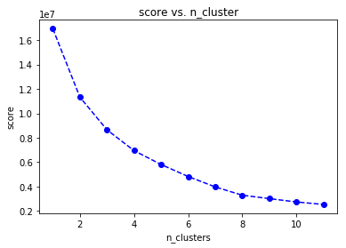

```python
# Investigate the change in within-cluster distance across number of clusters.
# HINT: Use matplotlib's plot function to visualize this relationship.

plt.plot(KMeansData["n_clusters"], KMeansData["score"], linestyle='--', marker='o', color='b');
plt.xlabel('n_clusters');
plt.ylabel('score');
plt.title('score vs. n_cluster');
```

```python
# Re-fit the k-means model with the selected number of clusters and obtain
# cluster predictions for the general population demographics data.
kmeans = KMeans(n_clusters=8, random_state=5)
KMFit = kmeans.fit(pcaResult)
KMLabels = KMFit.predict(pcaResult)
```

### Discussion 3.1: Apply Clustering to General Population

According to the ebow's rule, I used 8 clusters. The idea is understand the correlation between people who use to spend more money, their personality and population density

### Step 3.2: Apply All Steps to the Customer Data

Now that you have clusters and cluster centers for the general population, it's time to see how the customer data maps on to those clusters. Take care to not confuse this for re-fitting all of the models to the customer data. Instead, you're going to use the fits from the general population to clean, transform, and cluster the customer data. In the last step of the project, you will interpret how the general population fits apply to the customer data.

- Don't forget when loading in the customers data, that it is semicolon (`;`) delimited.
- Apply the same feature wrangling, selection, and engineering steps to the customer demographics using the `clean_data()` function you created earlier. (You can assume that the customer demographics data has similar meaning behind missing data patterns as the general demographics data.)
- Use the sklearn objects from the general demographics data, and apply their transformations to the customers data. That is, you should not be using a `.fit()` or `.fit_transform()` method to re-fit the old objects, nor should you be creating new sklearn objects! Carry the data through the feature scaling, PCA, and clustering steps, obtaining cluster assignments for all of the data in the customer demographics data.

```python
# Load in the customer demographics data.
customers = pd.read_csv("Udacity_CUSTOMERS_Subset.csv", delimiter=";")
```

```python
# Apply preprocessing, feature transformation, and clustering from the general
# demographics onto the customer data, obtaining cluster predictions for the
# customer demographics data.
customers = clean_data(customers)
```

[output not shown]

```python
len(azdiasNaN20.columns)
```

```
68
```

```python
len(customers.columns)
```

```
68
```

```python
customersScaled = scaler.transform(customers)
```

```python
customerPcaResults = pcaFit.transform(customersScaled)
```

```python
customerKMLabels = KMFit.predict(customerPcaResults)
```

### Step 3.3: Compare Customer Data to Demographics Data

At this point, you have clustered data based on demographics of the general population of Germany, and seen how the customer data for a mail-order sales company maps onto those demographic clusters. In this final substep, you will compare the two cluster distributions to see where the strongest customer base for the company is.

Consider the proportion of persons in each cluster for the general population, and the proportions for the customers. If we think the company's customer base to be universal, then the cluster assignment proportions should be fairly similar between the two. If there are only particular segments of the population that are interested in the company's products, then we should see a mismatch from one to the other. If there is a higher proportion of persons in a cluster for the customer data compared to the general population (e.g. 5% of persons are assigned to a cluster for the general population, but 15% of the customer data is closest to that cluster's centroid) then that suggests the people in that cluster to be a target audience for the company. On the other hand, the proportion of the data in a cluster being larger in the general population than the customer data (e.g. only 2% of customers closest to a population centroid that captures 6% of the data) suggests that group of persons to be outside of the target demographics.

Take a look at the following points in this step:

- Compute the proportion of data points in each cluster for the general population and the customer data. Visualizations will be useful here: both for the individual dataset proportions, but also to visualize the ratios in cluster representation between groups. Seaborn's [`countplot()`](https://seaborn.pydata.org/generated/seaborn.countplot.html) or [`barplot()`](https://seaborn.pydata.org/generated/seaborn.barplot.html) function could be handy.
  - Recall the analysis you performed in step 1.1.3 of the project, where you separated out certain data points from the dataset if they had more than a specified threshold of missing values. If you found that this group was qualitatively different from the main bulk of the data, you should treat this as an additional data cluster in this analysis. Make sure that you account for the number of data points in this subset, for both the general population and customer datasets, when making your computations!
- Which cluster or clusters are overrepresented in the customer dataset compared to the general population? Select at least one such cluster and infer what kind of people might be represented by that cluster. Use the principal component interpretations from step 2.3 or look at additional components to help you make this inference. Alternatively, you can use the `.inverse_transform()` method of the PCA and StandardScaler objects to transform centroids back to the original data space and interpret the retrieved values directly.
- Perform a similar investigation for the underrepresented clusters. Which cluster or clusters are underrepresented in the customer dataset compared to the general population, and what kinds of people are typified by these clusters?

```python
# Compare the proportion of data in each cluster for the customer data to the
# proportion of data in each cluster for the general population.

# general population
labelsUnique, labelsCount = np.unique(KMLabels, return_counts=True)
dfLabels = pd.DataFrame({"clusterLbl": labelsUnique,"populationLblCounts": labelsCount})
dfLabels
```

|  | clusterLbl | populationLblCounts |
| --- | --- | --- |
| 0 | 0 | 63652 |
| 1 | 1 | 86406 |
| 2 | 2 | 103313 |
| 3 | 3 | 53676 |
| 4 | 4 | 66275 |
| 5 | 5 | 86474 |
| 6 | 6 | 55386 |
| 7 | 7 | 108027 |

```python
customerLabelsUnique, customerlabelsCount = np.unique(customerKMLabels, return_counts=True)
dfCustomerLabels = pd.DataFrame({"clusterLbl": customerLabelsUnique,"customerLblCounts": customerlabelsCount})
dfCustomerLabels
```

|  | clusterLbl | customerLblCounts |
| --- | --- | --- |
| 0 | 0 | 1010 |
| 1 | 1 | 14225 |
| 2 | 2 | 22777 |
| 3 | 3 | 2763 |
| 4 | 4 | 1974 |
| 5 | 5 | 11650 |
| 6 | 6 | 1041 |
| 7 | 7 | 60203 |

```python
dfLabelsJoined = dfLabels.join(dfCustomerLabels, on="clusterLbl", how="inner", lsuffix="_", rsuffix="")[['clusterLbl', 'populationLblCounts', 'customerLblCounts']]
```

```python
display(dfLabelsJoined)
```

|  | clusterLbl | populationLblCounts | customerLblCounts |
| --- | --- | --- | --- |
| 0 | 0 | 63652 | 1010 |
| 1 | 1 | 86406 | 14225 |
| 2 | 2 | 103313 | 22777 |
| 3 | 3 | 53676 | 2763 |
| 4 | 4 | 66275 | 1974 |
| 5 | 5 | 86474 | 11650 |
| 6 | 6 | 55386 | 1041 |
| 7 | 7 | 108027 | 60203 |

```python
dfLabelsJoined["customerLblCountsPercent"] = dfLabelsJoined["customerLblCounts"]/dfLabelsJoined["customerLblCounts"].sum()
dfLabelsJoined["populationLblCountsPercent"] = dfLabelsJoined["populationLblCounts"]/dfLabelsJoined["populationLblCounts"].sum()
dfLabelsJoined["difference"] = dfLabelsJoined["populationLblCountsPercent"] - dfLabelsJoined["customerLblCountsPercent"]
dfLabelsJoined
```

|  | clusterLbl | populationLblCounts | customerLblCounts | customerLblCountsPercent | populationLblCountsPercent | difference |
| --- | --- | --- | --- | --- | --- | --- |
| 0 | 0 | 63652 | 1010 | 0.008734 | 0.102136 | 0.093402 |
| 1 | 1 | 86406 | 14225 | 0.123008 | 0.138647 | 0.015639 |
| 2 | 2 | 103313 | 22777 | 0.196960 | 0.165776 | -0.031184 |
| 3 | 3 | 53676 | 2763 | 0.023892 | 0.086128 | 0.062236 |
| 4 | 4 | 66275 | 1974 | 0.017070 | 0.106345 | 0.089275 |
| 5 | 5 | 86474 | 11650 | 0.100741 | 0.138756 | 0.038015 |
| 6 | 6 | 55386 | 1041 | 0.009002 | 0.088872 | 0.079870 |
| 7 | 7 | 108027 | 60203 | 0.520594 | 0.173340 | -0.347254 |

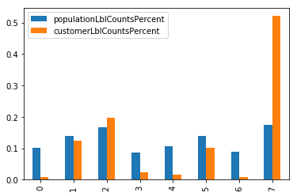

```python
dfLabelsJoined[["populationLblCountsPercent", "customerLblCountsPercent"]].plot(kind="bar");
```

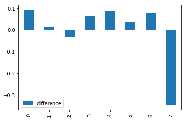

```python
dfLabelsJoined[["difference"]].plot(kind="bar");
```

Cluster 7 had the biggest difference, it was over represented in customer dataset. Also, cluster 2 is a little over represented as well. Cluster 0, 3, 4 and 6 are under-represented

```python
customers["labels"] = customerKMLabels
customers.head(10)
```

|  | ALTERSKATEGORIE_GROB | ANREDE_KZ | FINANZ_MINIMALIST | FINANZ_SPARER | FINANZ_VORSORGER | FINANZ_ANLEGER | FINANZ_UNAUFFAELLIGER | FINANZ_HAUSBAUER | GREEN_AVANTGARDE | HEALTH_TYP | ... | PLZ8_HHZ | PLZ8_GBZ | ARBEIT | ORTSGR_KLS9 | RELAT_AB | DECADE | MOVEMENT | WEALTHY | LIFESTAGE | labels |
| --- | --- | --- | --- | --- | --- | --- | --- | --- | --- | --- | --- | --- | --- | --- | --- | --- | --- | --- | --- | --- | --- |
| 0 | 4.0 | 1 | 5 | 1 | 5 | 1 | 2 | 2 | 1 | 1.0 | ... | 5.0 | 5.0 | 1.0 | 2.0 | 1.0 | 50 | 1.0 | 1 | 3 | 7 |
| 2 | 4.0 | 2 | 5 | 1 | 5 | 1 | 4 | 4 | 1 | 2.0 | ... | 3.0 | 2.0 | 3.0 | 5.0 | 3.0 | 50 | 1.0 | 3 | 4 | 5 |
| 4 | 3.0 | 1 | 3 | 1 | 4 | 4 | 5 | 2 | 0 | 3.0 | ... | 3.0 | 3.0 | 3.0 | 5.0 | 1.0 | 70 | 0.0 | 4 | 1 | 1 |
| 5 | 3.0 | 1 | 5 | 1 | 5 | 1 | 2 | 3 | 1 | 3.0 | ... | 5.0 | 5.0 | 3.0 | 7.0 | 5.0 | 50 | 1.0 | 3 | 4 | 7 |
| 6 | 4.0 | 1 | 5 | 1 | 5 | 1 | 1 | 2 | 1 | 2.0 | ... | 5.0 | 5.0 | 2.0 | 3.0 | 2.0 | 50 | 1.0 | 2 | 3 | 7 |
| 7 | 4.0 | 1 | 5 | 1 | 5 | 1 | 2 | 2 | 1 | 1.0 | ... | 3.0 | 3.0 | 3.0 | 4.0 | 3.0 | 50 | 1.0 | 1 | 5 | 7 |
| 9 | 3.0 | 1 | 5 | 2 | 4 | 1 | 3 | 1 | 1 | 3.0 | ... | 5.0 | 5.0 | 3.0 | 6.0 | 4.0 | 70 | 1.0 | 1 | 5 | 7 |
| 11 | 4.0 | 1 | 5 | 1 | 5 | 1 | 3 | 2 | 1 | 1.0 | ... | 3.0 | 3.0 | 2.0 | 5.0 | 1.0 | 50 | 1.0 | 1 | 4 | 7 |
| 12 | 4.0 | 1 | 5 | 2 | 4 | 3 | 2 | 1 | 0 | 2.0 | ... | 4.0 | 5.0 | 1.0 | 1.0 | 1.0 | 70 | 0.0 | 2 | 2 | 7 |
| 14 | 4.0 | 2 | 3 | 1 | 5 | 1 | 2 | 5 | 0 | 2.0 | ... | 5.0 | 3.0 | 3.0 | 8.0 | 5.0 | 40 | 0.0 | 5 | 1 | 5 |

10 rows × 69 columns

```python
# What kinds of people are part of a cluster that is overrepresented in the
# customer data compared to the general population?
overRepresented = customers[(customers["labels"] == 7) | (customers["labels"] == 2)]
overRepresentedFeatures = overRepresented[pcaMap['features'].values].mode().iloc[0].tolist()
```

```python
# What kinds of people are part of a cluster that is underrepresented in the
# customer data compared to the general population?
underRepresented = customers[(customers["labels"] == 0) |
                          (customers["labels"] == 3) |
                          (customers["labels"] == 4) |
                          (customers["labels"] == 6)]
underRepresentedFeatures = underRepresented[pcaMap['features'].values].mode().iloc[0].tolist()
```

```python
!cat Data_Dictionary.md
```

[output not shown]

[output cut: 774 more lines]

[output not shown]

```python
dfComparative = pd.DataFrame({"feature": pcaMap['features'].values,
                               "overRepresented": overRepresentedFeatures,
                             "underRepresented": underRepresentedFeatures})

display(dfComparative)
```

|  | feature | overRepresented | underRepresented |
| --- | --- | --- | --- |
| 0 | SEMIO_VERT | 7 | 6 |
| 1 | SEMIO_SOZ | 6 | 7 |
| 2 | ALTERSKATEGORIE_GROB | 4 | 2 |
| 3 | SEMIO_FAM | 4 | 7 |
| 4 | SEMIO_ERL | 7 | 2 |
| 5 | SEMIO_KULT | 4 | 7 |
| 6 | FINANZ_VORSORGER | 5 | 4 |
| 7 | PLZ8_ANTG3 | 1 | 1 |
| 8 | PLZ8_ANTG4 | 0 | 0 |
| 9 | PLZ8_BAUMAX | 1 | 1 |
| 10 | WEALTHY | 1 | 2 |
| 11 | HH_EINKOMMEN_SCORE | 1 | 5 |
| 12 | SEMIO_LUST | 7 | 2 |
| 13 | RETOURTYP_BK_S | 5 | 3 |
| 14 | FINANZ_MINIMALIST | 5 | 4 |

overRepresented:

```
- lowest affinity - dreamful,
- very low affinity - socially-minded
- average affinity - family-minded
- lowest affinity - event-oriented
- average affinity - cultural-minded
- > 60 years old,
- very low Financial typology
- lower share of 6-10 family homes
- no 10+ family homes
- lowest affinity - sensual-minded
- mainly 1-2 family homes
- highest household net income
- determined Minimal-Returner
```

underRepresented:

[output not shown]

### Discussion 3.3: Compare Customer Data to Demographics Data

**popular**: represented by people with 60+ years old, higher household net income, a little more family and cultural minded groups.

**unpopular**: represented by people with 30-45 years old, low household net income. As personality, is more event-oriented, a more sensual minded, low family and cultural minded.

> Congratulations on making it this far in the project! Before you finish, make sure to check through the entire notebook from top to bottom to make sure that your analysis follows a logical flow and all of your findings are documented in **Discussion** cells. Once you've checked over all of your work, you should export the notebook as an HTML document to submit for evaluation. You can do this from the menu, navigating to **File -> Download as -> HTML (.html)**. You will submit both that document and this notebook for your project submission.